[OHI Science](http://ohi-science.org) | [Citation policy](http://ohi-science.org/citation-policy/)

# OHI: Social Progress Index: Exploring gapfilling

Compiled on Thu Nov 16 16:19:45 2017 by frazier

# 1 Summary

This script gapfills the social progress index data and formats it for the OHI global assessment.

# 2 Updates

Previously, only one year of data were available, but now there are 4 years of data. Updated method of gapfilling. Now use Hmisc’s functions to gapfill missing data. This method is used to gapfill subcategories with 1 or more subsubcategories of data. We use the mean of 50 permutations using the “regression” method.

**Citation**: http://www.socialprogressimperative.org/

Stern, S., A. Wares and T. Epner. 2017. Social Progress Index: 2017 Methodology Report.

**Source information**: http://www.socialprogressimperative.org/global-index/ –> Export

**Date**: 8/10/2017

**Time range**: 2014-2017

**Native data resolution**: country scores

**Format**: Excel file

**Description**: Social Progress Index scores and components for countries.

```r
# load libraries, set directories
library(ohicore)  #devtools::install_github('ohi-science/ohicore@dev')
library(dplyr)
library(stringr)
library(tidyr)
library(Hmisc)
## comment out when knitting
#setwd("globalprep/prs_res_spi/v2017")


### Load FAO-specific user-defined functions
source('../../../src/R/common.R') # directory locations

set.seed(227)
```

# 3 Social Progress Index data

Organize data and gapfill missing countries that have incomplete data. This index is comprised of 3 indicators, which are each comprised of 4 subindicators, which are comprised of several datasets. If one of the subindicators are missing, the SPI is not calculated. The first round of gapfilling involves using relationships between the the subindicators to gapfill missing data. If a region is missing all subindicator data, then a second round of gapfilling is performed using relationships between UN geopolitical regions and the World Governance Indicator to gapfill the SPI score.

The following gets all years of data (currently in separate files).

```r
cats <- read.csv(file.path(dir_M, 'git-annex/globalprep/_raw_data/SocialProgressIndex/d2016/spi_categories.csv')) %>%
  mutate(category = gsub(" ", "", category))

files <- list.files(file.path(dir_M,
          "git-annex/globalprep/_raw_data/SocialProgressIndex/d2017"),
          pattern = "spi_", full = TRUE)

all_spi <- data.frame()

for(spi in files){ #spi = files[1]

spi_data <- read.csv(spi, check.names=FALSE, stringsAsFactors=FALSE)

names(spi_data) <- gsub(" ", "", names(spi_data))

yr <- substring(basename(spi), 5, 8)

spi_data <- spi_data %>%
  dplyr::select(-CountryCode) %>%
  mutate(year = yr) %>%
  gather('category', 'score', -Country, -year) %>%
  filter(category %in% cats$category) %>%
  left_join(cats, by = "category")

all_spi <- rbind(all_spi, spi_data)

}
```

## 3.1 Gapfilling: Step 1

In this case, we use relationships between the subindicators to estimate missing data.

### 3.1.1 Gapfill bhn indicator

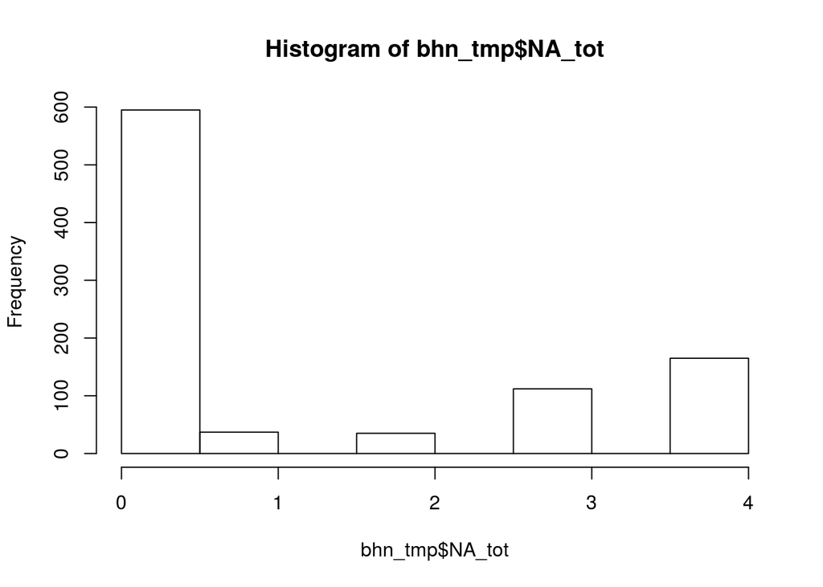

```r
set.seed(227)
bhn_subs <- all_spi %>%
  dplyr::filter(subcategory %in% c("bhn")) %>%
  spread(category, score)

bhn_tmp <- all_spi %>%
  dplyr::filter(subcategory %in% c("bhn_score")) %>%
  select(Country, year, bhn_score=score) %>%
  left_join(bhn_subs, by=c("Country", "year"))


bhn_tmp <- bhn_tmp %>%
rowwise() %>%
  mutate(NA_tot = sum(is.na(NutritionandBasicMedicalCare), is.na(NutritionandBasicMedicalCare), is.na(Shelter),
             is.na(WaterandSanitation)))
hist(bhn_tmp$NA_tot)
```

```r
table(bhn_tmp$NA_tot)
```

```
##
##   0   1   2   3   4
## 595  37  35 112 165
```

```r
#md.pattern(select(bhn_tmp, -(1:4))) # mice package

imputes <- 50
bhn_gf <- aregImpute(~ WaterandSanitation + Shelter + NutritionandBasicMedicalCare + PersonalSafety,
                         data = bhn_tmp, type = "regression", n.impute = imputes)
```

[output not shown]

```r
bhn_gf
```

```
##
## Multiple Imputation using Bootstrap and PMM
##
## aregImpute(formula = ~WaterandSanitation + Shelter + NutritionandBasicMedicalCare +
##     PersonalSafety, data = bhn_tmp, n.impute = imputes, type = "regression")
##
## n: 944   p: 4    Imputations: 50     nk: 3
##
## Number of NAs:
##           WaterandSanitation                      Shelter
##                          174                          311
## NutritionandBasicMedicalCare               PersonalSafety
##                          309                          322
##
##                              type d.f.
## WaterandSanitation              s    2
## Shelter                         s    2
## NutritionandBasicMedicalCare    s    2
## PersonalSafety                  s    1
##
## Transformation of Target Variables Forced to be Linear
##
## R-squares for Predicting Non-Missing Values for Each Variable
## Using Last Imputations of Predictors
##           WaterandSanitation                      Shelter
##                        0.877                        0.901
## NutritionandBasicMedicalCare               PersonalSafety
##                        0.848                        0.527
```

```r
# to get mean and sd of all imputations
impute_scores_all <- data.frame()

for (imp in 1:imputes){ #imp = 1

  imputed <- impute.transcan(bhn_gf, imputation=imp, data=bhn_tmp, list.out=TRUE,
                           pr=FALSE, check=FALSE)

      subcat_data <- data.frame(imputed)

      impute_scores <- data.frame(Country = bhn_tmp$Country,
                                  year = bhn_tmp$year,
                                  imputation = imp)

      impute_scores <- cbind(impute_scores, subcat_data)

      impute_scores_all <- rbind(impute_scores_all, impute_scores)
    }

impute_scores_summary <- impute_scores_all %>%
  gather("subcategory", "score", -(1:3)) %>%
  group_by(Country, year, subcategory) %>%
  dplyr::summarize(score_predict = mean(score),
            sd_score_predict = sd(score))
bhn_tmp_long <- bhn_tmp %>%
  select(Country, year, bhn_score, NA_tot, NutritionandBasicMedicalCare,
         PersonalSafety, Shelter, WaterandSanitation) %>%
  gather("subcategory", "score", -(1:4)) %>%
  left_join(impute_scores_summary, by=c("Country", "year", "subcategory"))
summary(bhn_tmp_long)
```

```
##    Country              year             bhn_score         NA_tot
##  Length:3776        Length:3776        Min.   :27.82   Min.   :0.000
##  Class :character   Class :character   1st Qu.:60.84   1st Qu.:0.000
##  Mode  :character   Mode  :character   Median :78.43   Median :0.000
##                                        Mean   :74.37   Mean   :1.168
##                                        3rd Qu.:88.62   3rd Qu.:3.000
##                                        Max.   :96.79   Max.   :4.000
##                                        NA's   :1492
##  subcategory            score        score_predict    sd_score_predict
##  Length:3776        Min.   :  6.96   Min.   :  6.96   Min.   : 0.000
##  Class :character   1st Qu.: 62.45   1st Qu.: 64.29   1st Qu.: 0.000
##  Mode  :character   Median : 78.86   Median : 77.22   Median : 0.000
##                     Mean   : 74.80   Mean   : 74.66   Mean   : 3.153
##                     3rd Qu.: 92.74   3rd Qu.: 90.36   3rd Qu.: 5.971
##                     Max.   :100.00   Max.   :100.00   Max.   :28.223
##                     NA's   :1116
```

```r
bhn_data <- bhn_tmp_long %>%
  mutate(score = ifelse(is.na(score) & NA_tot < 4, score_predict, score)) %>%
  group_by(Country, year) %>%
  dplyr::summarize( #bhn_score_old = mean(bhn_score), # used this to test to make sure all is well
            score = mean(score),
            NA_tot = mean(NA_tot)) %>%
  mutate(subcategory = "bhn")
```

### 3.1.2 Gapfill op indicator

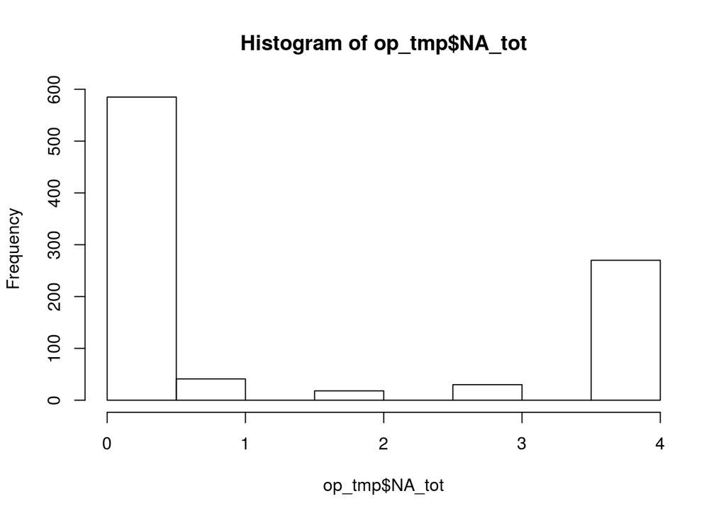

```r
set.seed(227)
op_subs <- all_spi %>%
  dplyr::filter(subcategory %in% c("op")) %>%
  spread(category, score)

op_tmp <- all_spi %>%
  dplyr::filter(subcategory %in% c("op_score")) %>%
  select(Country, year, op_score=score) %>%
  left_join(op_subs, by=c("Country", "year"))


op_tmp <- op_tmp %>%
rowwise() %>%
  mutate(NA_tot = sum(is.na(AccesstoAdvancedEducation), is.na(PersonalFreedomandChoice), is.na(PersonalRights),
             is.na(ToleranceandInclusion)))
hist(op_tmp$NA_tot)
```

```r
table(op_tmp$NA_tot)
```

```
##
##   0   1   2   3   4
## 585  41  18  30 270
```

```r
#md.pattern(select(op_tmp, -(1:4))) # mice package

imputes <- 50
op_gf <- aregImpute(~ AccesstoAdvancedEducation + PersonalFreedomandChoice + PersonalRights + ToleranceandInclusion,
                         data = op_tmp, type = "regression", n.impute = imputes)
```

[output not shown]

```r
op_gf
```

```
##
## Multiple Imputation using Bootstrap and PMM
##
## aregImpute(formula = ~AccesstoAdvancedEducation + PersonalFreedomandChoice +
##     PersonalRights + ToleranceandInclusion, data = op_tmp, n.impute = imputes,
##     type = "regression")
##
## n: 944   p: 4    Imputations: 50     nk: 3
##
## Number of NAs:
## AccesstoAdvancedEducation  PersonalFreedomandChoice
##                       301                       313
##            PersonalRights     ToleranceandInclusion
##                       298                       335
##
##                           type d.f.
## AccesstoAdvancedEducation    s    2
## PersonalFreedomandChoice     s    2
## PersonalRights               s    2
## ToleranceandInclusion        s    1
##
## Transformation of Target Variables Forced to be Linear
##
## R-squares for Predicting Non-Missing Values for Each Variable
## Using Last Imputations of Predictors
## AccesstoAdvancedEducation  PersonalFreedomandChoice
##                     0.591                     0.761
##            PersonalRights     ToleranceandInclusion
##                     0.512                     0.640
```

```r
# to get mean and sd of all imputations
impute_scores_all <- data.frame()

for (imp in 1:imputes){ #imp = 1

  imputed <- impute.transcan(op_gf, imputation=imp, data=op_tmp, list.out=TRUE,
                           pr=FALSE, check=FALSE)

      subcat_data <- data.frame(imputed)

      impute_scores <- data.frame(Country = op_tmp$Country,
                                  year = op_tmp$year,
                                  imputation = imp)

      impute_scores <- cbind(impute_scores, subcat_data)

      impute_scores_all <- rbind(impute_scores_all, impute_scores)
    }

impute_scores_summary <- impute_scores_all %>%
  gather("subcategory", "score", -(1:3)) %>%
  group_by(Country, year, subcategory) %>%
  dplyr::summarize(score_predict = mean(score),
            sd_score_predict = sd(score))
op_tmp_long <- op_tmp %>%
  select(Country, year, op_score, NA_tot, AccesstoAdvancedEducation,
         PersonalFreedomandChoice, PersonalRights, ToleranceandInclusion) %>%
  gather("subcategory", "score", -(1:4)) %>%
  left_join(impute_scores_summary, by=c("Country", "year", "subcategory"))
summary(op_tmp_long)
```

```
##    Country              year              op_score         NA_tot
##  Length:3776        Length:3776        Min.   :21.90   Min.   :0.000
##  Class :character   Class :character   1st Qu.:40.69   1st Qu.:0.000
##  Mode  :character   Mode  :character   Median :50.11   Median :0.000
##                                        Mean   :53.36   Mean   :1.321
##                                        3rd Qu.:63.62   3rd Qu.:4.000
##                                        Max.   :88.83   Max.   :4.000
##                                        NA's   :1436
##  subcategory            score       score_predict   sd_score_predict
##  Length:3776        Min.   : 3.45   Min.   : 3.45   Min.   : 0.000
##  Class :character   1st Qu.:38.74   1st Qu.:40.06   1st Qu.: 0.000
##  Mode  :character   Median :53.13   Median :51.54   Median : 0.000
##                     Mean   :52.65   Mean   :51.51   Mean   : 4.936
##                     3rd Qu.:67.96   3rd Qu.:62.77   3rd Qu.:11.090
##                     Max.   :97.89   Max.   :97.89   Max.   :27.051
##                     NA's   :1247
```

```r
op_data <- op_tmp_long %>%
  mutate(score = ifelse(is.na(score) & NA_tot < 4, score_predict, score)) %>%
  group_by(Country, year) %>%
  dplyr::summarize( #op_score_old = mean(op_score), # used this to test to make sure all is well
            score = mean(score),
            NA_tot = mean(NA_tot)) %>%
  mutate(subcategory = "op")
```

### 3.1.3 Gapfill fw indicator

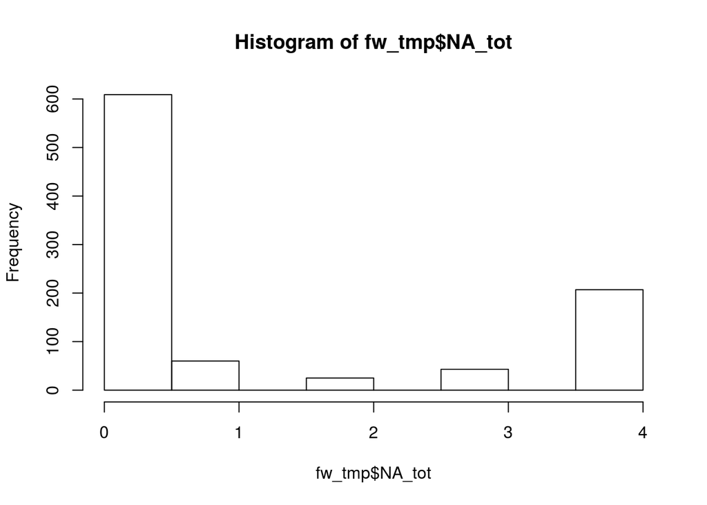

```r
set.seed(227)
fw_subs <- all_spi %>%
  dplyr::filter(subcategory %in% c("fw")) %>%
  spread(category, score)

fw_tmp <- all_spi %>%
  dplyr::filter(subcategory %in% c("fw_score")) %>%
  select(Country, year, fw_score=score) %>%
  left_join(fw_subs, by=c("Country", "year"))


fw_tmp <- fw_tmp %>%
rowwise() %>%
  mutate(NA_tot = sum(is.na(AccesstoBasicKnowledge), is.na(AccesstoInformationandCommunications),
                      is.na(EnvironmentalQuality),is.na(HealthandWellness)))
hist(fw_tmp$NA_tot)
```

```r
table(fw_tmp$NA_tot)
```

```
##
##   0   1   2   3   4
## 609  60  25  43 207
```

```r
#md.pattern(select(fw_tmp, -(1:4))) # mice package

imputes <- 50
fw_gf <- aregImpute(~ AccesstoBasicKnowledge + AccesstoInformationandCommunications + EnvironmentalQuality + HealthandWellness,
                         data = fw_tmp, type = "regression", n.impute = imputes)
```

[output not shown]

```r
fw_gf
```

```
##
## Multiple Imputation using Bootstrap and PMM
##
## aregImpute(formula = ~AccesstoBasicKnowledge + AccesstoInformationandCommunications +
##     EnvironmentalQuality + HealthandWellness, data = fw_tmp,
##     n.impute = imputes, type = "regression")
##
## n: 944   p: 4    Imputations: 50     nk: 3
##
## Number of NAs:
##               AccesstoBasicKnowledge AccesstoInformationandCommunications
##                                  285                                  256
##                 EnvironmentalQuality                    HealthandWellness
##                                  297                                  229
##
##                                      type d.f.
## AccesstoBasicKnowledge                  s    2
## AccesstoInformationandCommunications    s    2
## EnvironmentalQuality                    s    2
## HealthandWellness                       s    1
##
## Transformation of Target Variables Forced to be Linear
##
## R-squares for Predicting Non-Missing Values for Each Variable
## Using Last Imputations of Predictors
##               AccesstoBasicKnowledge AccesstoInformationandCommunications
##                                0.535                                0.630
##                 EnvironmentalQuality                    HealthandWellness
##                                0.766                                0.553
```

```r
# to get mean and sd of all imputations
impute_scores_all <- data.frame()

for (imp in 1:imputes){ #imp = 1

  imputed <- impute.transcan(fw_gf, imputation=imp, data=fw_tmp, list.out=TRUE,
                           pr=FALSE, check=FALSE)

      subcat_data <- data.frame(imputed)

      impute_scores <- data.frame(Country = fw_tmp$Country,
                                  year = fw_tmp$year,
                                  imputation = imp)

      impute_scores <- cbind(impute_scores, subcat_data)

      impute_scores_all <- rbind(impute_scores_all, impute_scores)
    }

impute_scores_summary <- impute_scores_all %>%
  gather("subcategory", "score", -(1:3)) %>%
  group_by(Country, year, subcategory) %>%
  dplyr::summarize(score_predict = mean(score),
            sd_score_predict = sd(score))
fw_tmp_long <- fw_tmp %>%
  select(Country, year, fw_score, NA_tot, AccesstoBasicKnowledge,
         AccesstoInformationandCommunications, EnvironmentalQuality, HealthandWellness) %>%
  gather("subcategory", "score", -(1:4)) %>%
  left_join(impute_scores_summary, by=c("Country", "year", "subcategory"))
summary(fw_tmp_long)
```

```
##    Country              year              fw_score         NA_tot
##  Length:3776        Length:3776        Min.   :35.18   Min.   :0.00
##  Class :character   Class :character   1st Qu.:59.48   1st Qu.:0.00
##  Mode  :character   Mode  :character   Median :72.52   Median :0.00
##                                        Mean   :70.50   Mean   :1.13
##                                        3rd Qu.:80.67   3rd Qu.:3.00
##                                        Max.   :91.75   Max.   :4.00
##                                        NA's   :1340
##  subcategory            score       score_predict   sd_score_predict
##  Length:3776        Min.   : 7.99   Min.   : 7.99   Min.   : 0.000
##  Class :character   1st Qu.:57.59   1st Qu.:58.24   1st Qu.: 0.000
##  Mode  :character   Median :70.36   Median :67.62   Median : 0.000
##                     Mean   :70.10   Mean   :69.24   Mean   : 3.313
##                     3rd Qu.:83.65   3rd Qu.:81.55   3rd Qu.: 8.639
##                     Max.   :99.86   Max.   :99.86   Max.   :19.815
##                     NA's   :1067
```

```r
fw_data <- fw_tmp_long %>%
  mutate(score = ifelse(is.na(score) & NA_tot < 4, score_predict, score)) %>%
  group_by(Country, year) %>%
  dplyr::summarize( #fw_score_old = mean(fw_score), # used this to test to make sure all is well
            score = mean(score),
            NA_tot = mean(NA_tot)) %>%
  mutate(subcategory = "fw")
```

## 3.2 Combine data to get Social Progress Index

The next step averages the 3 indicators and identifies gapfilling.

```r
spi_calc <- rbind(bhn_data, op_data, fw_data) %>%
  mutate(gapfill = paste(subcategory, NA_tot, sep = "_")) %>%
  mutate(score = ifelse(score > 100, 100, score),
         score = ifelse(score < 0, 0, score)) %>%
  group_by(Country, year) %>%
  dplyr::summarize(score = mean(score),
            method = paste(unique(gapfill), collapse=", "),
            gapfill = sum(NA_tot)) %>%
  mutate(method = ifelse(gapfill == 0, NA, method),
         gapfill = ifelse(gapfill >= 1, 1, 0)) %>%
  data.frame()

# check:
check <- spi_data %>%
  filter(category=="SocialProgressIndex") %>%
  dplyr::select(Country, year, true_score=score) %>%
  left_join(spi_calc)
```

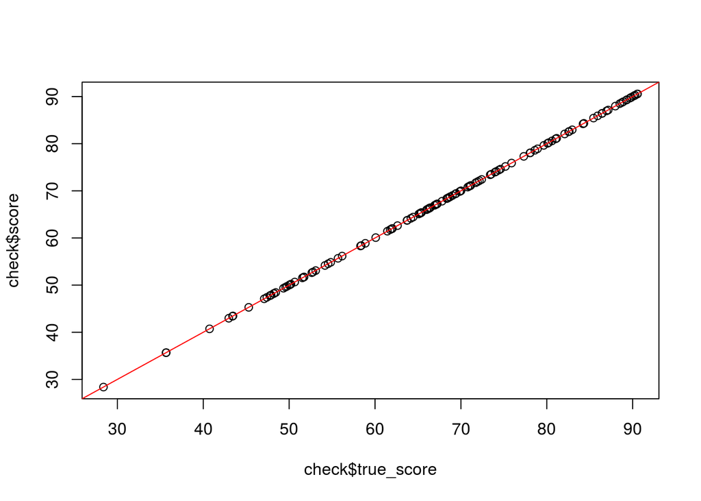

```r
plot(check$true_score, check$score)
abline(0,1, col="red")
```

```r
write.csv(spi_calc, "int/Country_spi.csv", row.names=FALSE)
```

## 3.3 Assign countries to OHI regions

```r
spi_calc <- read.csv("int/Country_spi.csv", stringsAsFactors = FALSE)
spi_calc <- spi_calc %>%
  mutate(Country = ifelse(Country=="C<f4>te d'Ivoire", "Cote d'Ivoire", Country),
         Country = ifelse(Country=="R<e9>union", "Reunion", Country),
         Country = ifelse(Country=="Cura<e7>ao", "Curacao", Country),
         Country = ifelse(Country=="Korea, Democratic Republic of", "North Korea", Country),
         Country = ifelse(Country=="St. Helena", "Saint Helena", Country),
         Country = ifelse(Country=="St. Martin", "Northern Saint-Martin", Country))

# Channel Islands are Jersey and Guernsey, but these are already in the data


spi_rgn <- name_2_rgn(df_in = spi_calc,
                       fld_name='Country',
                      flds_unique = c("year"))
```

```
##
## These data were removed for not having any match in the lookup tables:
##
## Channel Islands    North Cyprus      Somaliland    Vatican City
##               1               1               1               1
##
## These data were removed for not being of the proper rgn_type (eez,ohi_region) or mismatching region names in the lookup tables:
##                           tmp_type
## tmp_name                   disputed landlocked
##   Afghanistan                     0          4
##   Andorra                         0          4
##   Armenia                         0          4
##   Austria                         0          4
##   Belarus                         0          4
##   Bhutan                          0          4
##   Bolivia                         0          4
##   Botswana                        0          4
##   Burkina Faso                    0          4
##   Burundi                         0          4
##   Central African Republic        0          4
##   Chad                            0          4
##   Czech Republic                  0          4
##   Ethiopia                        0          4
##   Hungary                         0          4
##   Kazakhstan                      0          4
##   Kosovo                          0          4
##   Kyrgyzstan                      0          4
##   Laos                            0          4
##   Lesotho                         0          4
##   Liechtenstein                   0          4
##   Luxembourg                      0          4
##   Macedonia                       0          4
##   Malawi                          0          4
##   Mali                            0          4
##   Moldova                         0          4
##   Mongolia                        0          4
##   Nepal                           0          4
##   Niger                           0          4
##   Paraguay                        0          4
##   Rwanda                          0          4
##   San Marino                      0          4
##   Serbia                          0          4
##   Slovakia                        0          4
##   South Sudan                     0          4
##   Swaziland                       0          4
##   Switzerland                     0          4
##   Tajikistan                      0          4
##   Turkmenistan                    0          4
##   Uganda                          0          4
##   Uzbekistan                      0          4
##   West Bank and Gaza              4          0
##   Zambia                          0          4
##   Zimbabwe                        0          4
```

```
##
## DUPLICATES found. Consider using collapse2rgn to collapse duplicates (function in progress).
```

```
## [1] "China"                    "Guadeloupe"
## [3] "Guam"                     "Hong Kong"
## [5] "Macao"                    "Martinique"
## [7] "Northern Mariana Islands" "Puerto Rico"
## [9] "Virgin Islands (U.S.)"
```

```r
# Weight the following duplicates by population
# Northern Mariana Islands and Guam
# China, Macao, Hong Kong
# Puerto Rico and Virgin Islands (U.S.)
# Guadeloupe and Martinique

pop_weights <- data.frame(Country = c("China", "Hong Kong", "Macao",
                 "Guadeloupe", "Martinique",
                 "Guam", "Northern Mariana Islands",
                 "Puerto Rico", "Virgin Islands (U.S.)"),
                 pop = c(1389315824, 7184000, 614500,
                         404394, 399637,
                         159358, 53833,
                         3411000, 102951))
spi_rgn <- spi_rgn %>%
  left_join(pop_weights, by = "Country") %>%
  mutate(pop = ifelse(is.na(pop), 1, pop)) %>%
  group_by(rgn_id, rgn_name, year) %>%
  dplyr::summarize(score = weighted.mean(score, pop, na.rm=TRUE),
            method = paste(unique(method), collapse=" "),
            gapfill = weighted.mean(gapfill, pop, na.rm=TRUE))%>%
  dplyr::mutate(year = as.numeric(as.character(year)))
```

# 4 Compare to WGI

WGI is a couple years behind the SPI, so we will use 2015 WGI for the 2016 and 2017 SPI. There is a strong correlation betwen the WGI and SPI indicators.

```r
wgi <- read.csv('../../prs_res_wgi/v2017/output/wgi_res.csv') %>%
  select(rgn_id, year, wgi_score =resilience_score)

length(unique(wgi$rgn_id))
```

```
## [1] 220
```

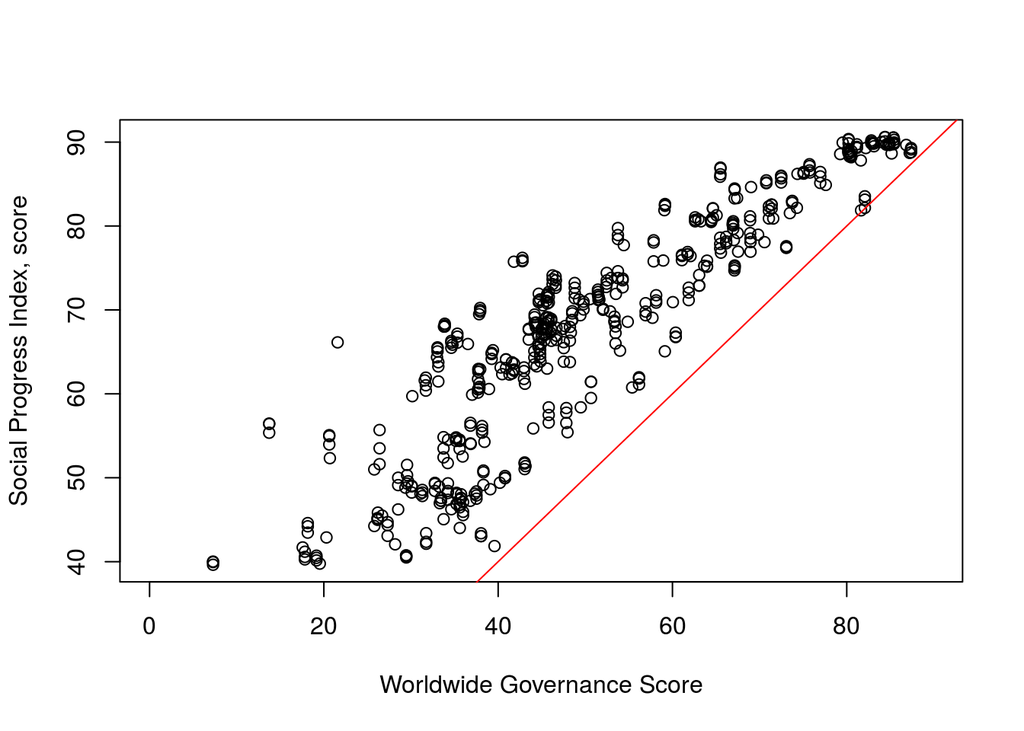

```r
wgi_2016 <- wgi %>%
  filter(year == 2015) %>%
  mutate(year = 2016)

wgi_2017 <- wgi %>%
  filter(year == 2015) %>%
  mutate(year = 2017)

wgi <- rbind(wgi, wgi_2016, wgi_2017)

wgi_spi <- wgi %>%
  left_join(spi_rgn, by=c("rgn_id", "year"))

plot(wgi_spi$wgi_score*100, wgi_spi$score, ylab="Social Progress Index, score", xlab="Worldwide Governance Score")
abline(0,1, col="red")
```

```r
mod <- lm(score ~ wgi_score, data=wgi_spi)
summary(mod)
```

```
##
## Call:
## lm(formula = score ~ wgi_score, data = wgi_spi)
##
## Residuals:
##      Min       1Q   Median       3Q      Max
## -18.0691  -3.6754   0.3509   3.8445  18.9330
##
## Coefficients:
##             Estimate Std. Error t value Pr(>|t|)
## (Intercept)  31.9488     0.8011   39.88   <2e-16 ***
## wgi_score    70.6996     1.4979   47.20   <2e-16 ***
## ---
## Signif. codes:  0 '***' 0.001 '**' 0.01 '*' 0.05 '.' 0.1 ' ' 1
##
## Residual standard error: 6.01 on 503 degrees of freedom
##   (3675 observations deleted due to missingness)
## Multiple R-squared:  0.8158, Adjusted R-squared:  0.8154
## F-statistic:  2228 on 1 and 503 DF,  p-value: < 2.2e-16
```

# 5 Second round of gapfilling

```r
years <- data.frame(year = min(spi_rgn$year):max(spi_rgn$year))

rgns_gf_un <-  georegions %>%
  merge(years) %>%
  left_join(spi_rgn) %>%
  left_join(wgi) %>%
  mutate(r2 = as.factor(r2)) %>%
  mutate(r1 = as.factor(r1))
```

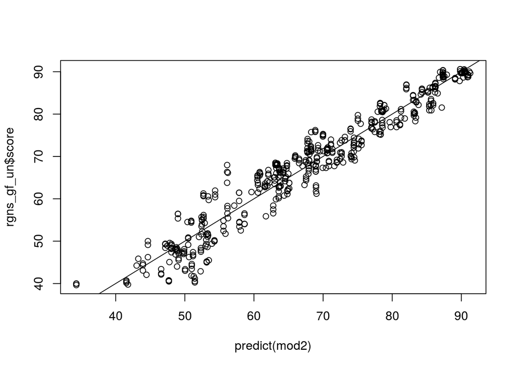

```r
## Compare models to select a gapfilling method
mod1 <- lm(score ~ r2, data = rgns_gf_un, na.action="na.exclude")
mod2 <- lm(score ~ r2 + wgi_score, data = rgns_gf_un, na.action="na.exclude")

mod3 <- lm(score ~ r1, data = rgns_gf_un)
mod4 <- lm(score ~ r1 + wgi_score, data = rgns_gf_un, na.action="na.exclude")

mod5 <- lm(score ~ wgi_score, data = rgns_gf_un)

mod6 <- lm(score ~ r1 + poly(wgi_score, 2), data = rgns_gf_un, na.action = "na.exclude")
mod7 <- lm(score ~ r1 + poly(wgi_score, 3), data = rgns_gf_un, na.action = "na.exclude")

plot(predict(mod2), rgns_gf_un$score)
abline(0,1)
```

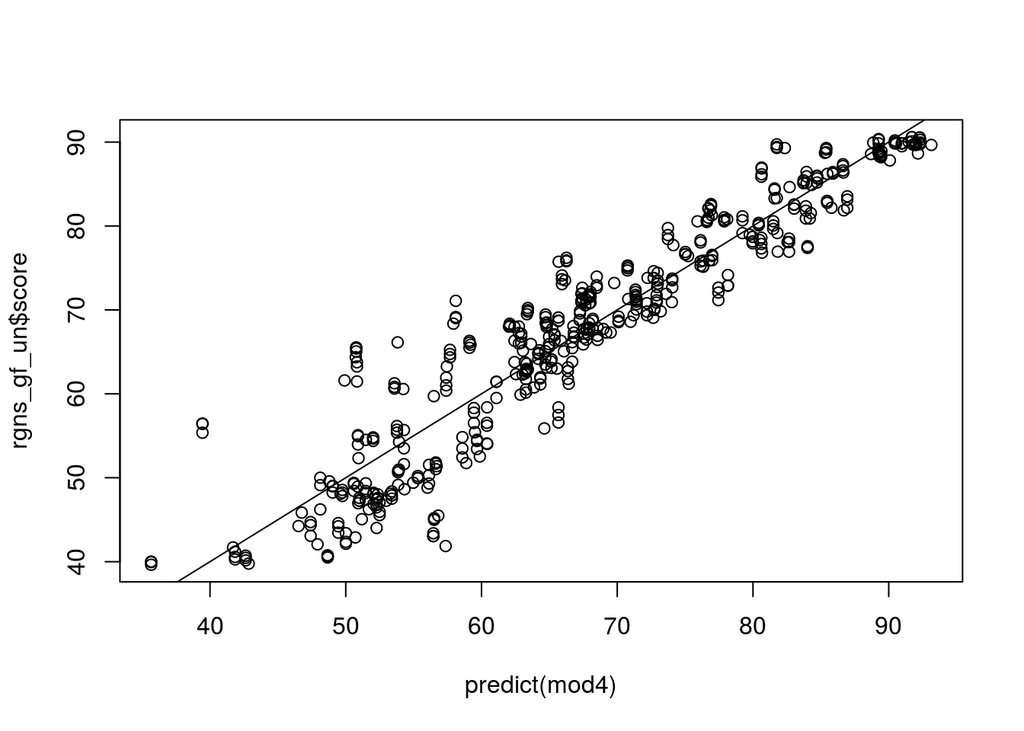

```r
plot(predict(mod4), rgns_gf_un$score)
abline(0,1)
```

```r
AIC(mod1, mod2, mod3, mod4, mod5, mod6, mod7)
```

```
##      df      AIC
## mod1 20 3504.106
## mod2 21 2751.701
## mod3  7 3697.777
## mod4  8 3010.485
## mod5  3 3248.505
## mod6  9 3012.075
## mod7 10 3003.764
```

```r
## Estimate missing data and gapfill
## need to add this because some R2 regions have no data
r2_regions <- unique(rgns_gf_un$r2[!is.na(rgns_gf_un$score)])
rgns_gf_un$r2 <- ifelse(rgns_gf_un$r2 %in% r2_regions, rgns_gf_un$r2, NA)

r1_regions <- unique(rgns_gf_un$r1[!is.na(rgns_gf_un$score)])
rgns_gf_un$r1 <- ifelse(rgns_gf_un$r1 %in% r1_regions, rgns_gf_un$r1, NA)


mod_gf_r2 <- lm(score ~ r2 + wgi_score, data = rgns_gf_un, na.action = na.exclude)
rgns_gf_un$score_pred_r2 <- predict(mod_gf_r2, newdata = rgns_gf_un[, c("r2", "wgi_score")])

mod_gf_r1 <- lm(score ~ r1 + wgi_score, data = rgns_gf_un, na.action = na.exclude)
rgns_gf_un$score_pred_r1 <- predict(mod_gf_r1, newdata = rgns_gf_un[, c("r1", "wgi_score")])

mod_gf_wgi <- lm(score ~ wgi_score, data = rgns_gf_un, na.action = na.exclude)
rgns_gf_un$score_pred_wgi <- predict(mod_gf_wgi, newdata = data.frame(wgi_score = rgns_gf_un$wgi_score))


rgns_gf <- rgns_gf_un %>%
  mutate(method = ifelse(is.na(score), "UN georgn & WGI", method)) %>%
  mutate(gapfill = ifelse(is.na(score), "1", gapfill)) %>%
  mutate(score = ifelse(is.na(score), score_pred_r2, score)) %>%
  mutate(score = ifelse(is.na(score), score_pred_r1, score)) %>%
  mutate(score = ifelse(is.na(score), score_pred_wgi, score)) %>%
  select(rgn_id, year, score, method, gapfill) %>%
  mutate(score = ifelse(score > 100, 100, score),
         score = ifelse(score < 0, 0, score))

summary(rgns_gf)  # should be no NA values
```

```
##      rgn_id            year          score          method
##  Min.   :  1.00   Min.   :2014   Min.   :36.22   Length:880
##  1st Qu.: 58.75   1st Qu.:2015   1st Qu.:63.49   Class :character
##  Median :116.50   Median :2016   Median :72.82   Mode  :character
##  Mean   :117.64   Mean   :2016   Mean   :70.82
##  3rd Qu.:176.25   3rd Qu.:2016   3rd Qu.:80.83
##  Max.   :250.00   Max.   :2017   Max.   :93.18
##    gapfill
##  Length:880
##  Class :character
##  Mode  :character
##
##
##
```

```r
length(unique(rgns_gf$rgn_id)) # should be 220 regions
```

```
## [1] 220
```

# 6 Uninhabited regions

These regions will receive an NA for their score (when established population is < 100 people).

```r
uninhab <- read.csv('../../../src/LookupTables/rgn_uninhabited_islands.csv') %>%
  filter(is.na(est_population) | est_population < 100)

rgns_gf_uninhab <- rgns_gf %>%
  mutate(score = ifelse(rgn_id %in% uninhab$rgn_id, NA, score)) %>%
  mutate(gapfill = ifelse(rgn_id %in% uninhab$rgn_id, NA, gapfill))
```

# 7 Save final data

```r
gf_data <- rgns_gf_uninhab %>%
  select(rgn_id, year, gapfill, method) %>%
  mutate(gapfill = ifelse(is.na(method), 0, 1))
write.csv(gf_data, "output/spi_gf.csv", row.names=FALSE)


res_data <- rgns_gf_uninhab %>%
  select(rgn_id, year, resilience_score=score) %>%
  mutate(resilience_score = resilience_score/100)
write.csv(res_data, "output/spi_res.csv", row.names=FALSE)

prs_data <- rgns_gf_uninhab %>%
  select(rgn_id, year, pressure_score=score) %>%
  mutate(pressure_score = 1 - (pressure_score/100))
write.csv(prs_data, "output/spi_prs.csv", row.names=FALSE)
```